# Segmentation Insights: Navigating User Paths for Better Conversions

**by Crystal Huang**  
Data Mining, Discovery, and Exploration  
Harvard Extension School  
Spring 2025

## 1. Executive Summary

This project uses Google Analytics 4 (GA4) e-commerce data from the [Google Merchandise Store](https://shop.googlemerchandisestore.com/) for December 2020 to address two interconnected business challenges: **behavioral segmentation and user journey analysis**. By segmenting users based on aggregated browsing and engagement patterns and analyzing navigation flows, this study aims to provide actionable insights for targeted marketing, enhanced user experiences, and improved conversion rates.

E-commerce platforms like the Google Merchandise Store often struggle to understand how visitor behaviors vary and what patterns contribute to conversions or drop-offs. To address this, the project applies clustering algorithms to group users with similar behavioral profiles and graph-based models to analyze their navigation paths.

After exploring both session-level and user-level aggregation, the analysis focused on the user level to better capture consistent behavioral patterns across visits. Feature engineering, data transformation, dimensionality reduction, and a range of clustering techniques (K-Means, DBSCAN, and OPTICS) were used to uncover distinct user segments. Among these clustering methods, DBSCAN proved most effective, surfacing more nuanced clusters that closely reflected differences in user engagement.

To better understand what differentiates users who convert from those who don’t, a graph-based analysis of user journeys was run on key clusters. Comparing high-intent browsers to actual purchasers highlighted differences in navigation flows, points of friction, and how users interacted with features like wishlists and info pages. These patterns helped surface opportunities to improve the user experience and encourage more users to complete their path to purchase.

## 2. Data Overview

The project utilizes an updated version of the `ga4_obfuscated_sample_ecommerce` dataset available through [the BigQuery Public Datasets program](https://developers.google.com/analytics/bigquery/web-ecommerce-demo-dataset). This dataset contains obfuscated Google Analytics 4 (GA4) event export data from the Google Merchandise Store for December 2020. It captures detailed user interactions with the website, including product views, purchases, and engagement activities.

| Column | Description |
| --- | --- |
| user_pseudo_id | Anonymous unique identifier for users |
| ga_session_id | Identifier for user sessions |
| event_timestamp | Timestamp of the event |
| event_name | Name of the event (e.g., page_view, purchase) |
| event_category | Event category (passive,engagement,purchase) |
| cleaned_page_title | Page title (cleaned) |
| page_category | Page category (account_page, home_page, checkout_page, product_catalog_page, info_page, product_page, search_page, error_page, request_page, wishlist_page) |
| device_category | Type of device (e.g., mobile, desktop) |
| device_mobile_brand_name | Mobile device brand |
| geo_continent | Continent of the user |

Due to high cardinality and sparsity, the `geo_country` field was excluded from the cleaned dataset. Regional information was retained via the `geo_continent` variable to balance geographic context with dimensionality considerations. In addition, cleaning and categorization were applied to the `event_category`, `cleaned_page_title`, and `page_category` columns to reduce high cardinality and inconsistent granularity. These fields were grouped into broader, standardized categories using business logic to improve interpretability and support analysis.

```python
import pandas as pd
import numpy as np
import numpy.random as nr
import matplotlib.pyplot as plt
import seaborn as sns
from functools import reduce

from scipy import stats
from statsmodels.distributions.empirical_distribution import ECDF
from sklearn.preprocessing import power_transform
import umap.umap_ as umap
from sklearn.cluster import KMeans, DBSCAN, OPTICS
from sklearn.metrics import silhouette_score, calinski_harabasz_score
import networkx as nx
from itertools import tee

from joblib import Parallel, delayed
from tqdm import tqdm
import warnings
warnings.filterwarnings('ignore')

sns.set_theme(style="whitegrid")
sns.set_palette("deep")
sns.set_context("notebook", font_scale=1.2)
```

```python
def import_data(filepath):
    df = pd.read_parquet(filepath)
    df = df.drop(columns=["geo_country"])
    print('Number of rows:', df.shape[0])
    print('Number of columns:', df.shape[1])

    summary = pd.DataFrame({
        'Data Type': df.dtypes,
        'Non-Null Count': df.count()
    })

    print('\nVariable Summary:')
    display(summary)

    print('\nData Preview:')
    display(df.head(2))
    return df

df = import_data("ga4_data/ga4_project_data.parquet")
```

```
Number of rows: 1071172
Number of columns: 10

Variable Summary:
```

|  | Data Type | Non-Null Count |
| --- | --- | --- |
| user_pseudo_id | object | 1071172 |
| ga_session_id | float64 | 1071172 |
| event_timestamp | datetime64[ns] | 1071172 |
| event_name | object | 1071172 |
| event_category | object | 1071172 |
| cleaned_page_title | object | 1071172 |
| page_category | object | 1071172 |
| device_category | object | 1071172 |
| device_mobile_brand_name | object | 1071172 |
| geo_continent | object | 1071172 |

```
Data Preview:
```

|  | user_pseudo_id | ga_session_id | event_timestamp | event_name | event_category | cleaned_page_title | page_category | device_category | device_mobile_brand_name | geo_continent |
| --- | --- | --- | --- | --- | --- | --- | --- | --- | --- | --- |
| 0 | 11106892.6823829951 | 4.079111e+09 | 2020-12-01 00:23:09 | page_view | passive | Log In | account_page | mobile | Apple | Americas |
| 1 | 26093472.8597941925 | 6.247282e+09 | 2020-12-01 22:57:00 | scroll | passive | Home | home_page | desktop | Google | Asia |

## 3. Data Preparation and Exploration

### 3.1 Session-Level Feature Engineering (for Exploratory Analysis)

To support exploratory analysis, the cleaned event-level GA4 data was aggregated into a session-level dataset. Each row represents a single session and includes features capturing temporal patterns, engagement signals, and contextual attributes.

**Temporal Features:**

- Converted timestamps and sorted events chronologically.
- Calculated time gaps between events and average time per session.
- Computed session duration, start hour, and day of week.

**Engagement Features:**

- Counted total and unique events per session.
- Summarized event categories (e.g., passive, engagement, purchase).
- Counted page views by category (e.g., product, checkout).
- Captured first/last events and landing/exit pages.

**Contextual Features:** Extracted device type, mobile brand, and geographic location from the first event.

This dataset was used for behavioral exploration and guided the construction of user-level features but was not included in clustering.

```python
df_event = df.copy()
df_event['event_timestamp'] = pd.to_datetime(df_event['event_timestamp'])
df_event = df_event.sort_values(['user_pseudo_id', 'ga_session_id', 'event_timestamp'])

# Session-level features
df_event['time_diff'] = df_event.groupby(['user_pseudo_id', 'ga_session_id'])['event_timestamp'].diff().dt.total_seconds()
avg_time_between = df_event.groupby(['user_pseudo_id', 'ga_session_id'])['time_diff'] \
                     .mean().reset_index(name='avg_time_between_events')

session_times = df_event.groupby(['user_pseudo_id', 'ga_session_id']).agg(
    session_start=('event_timestamp', 'min'),
    session_end=('event_timestamp', 'max')
).reset_index()
session_times['session_duration'] = (session_times['session_end'] - session_times['session_start']).dt.total_seconds()
session_times['session_hour'] = session_times['session_start'].dt.hour
session_times['session_dayofweek'] = session_times['session_start'].dt.day_name()

# Engagement features
event_counts = df_event.groupby(['user_pseudo_id', 'ga_session_id']).agg(
    num_events_total=('event_name', 'count'),
    num_event_names=('event_name', 'nunique')
).reset_index()

event_types = df_event.groupby(['user_pseudo_id', 'ga_session_id', 'event_category'])['event_name'] \
                .count().unstack(fill_value=0).reset_index()
event_types = event_types.rename(columns=lambda x: f'num_{x}_events' if x not in ['user_pseudo_id', 'ga_session_id'] else x)

page_category_counts = df_event.groupby(['user_pseudo_id', 'ga_session_id', 'page_category'])['event_name'] \
                         .count().unstack(fill_value=0).reset_index()
page_category_counts = page_category_counts.rename(columns=lambda x: f'num_{x}_pages' if x not in ['user_pseudo_id', 'ga_session_id'] else x)

first_last_events = df_event.groupby(['user_pseudo_id', 'ga_session_id']).agg(
    first_event=('event_name', lambda x: x.iloc[0]),
    last_event=('event_name', lambda x: x.iloc[-1])
).reset_index()

# First and last page categories and titles
first_last_pages = df_event.groupby(['user_pseudo_id', 'ga_session_id']).agg(
    first_page_category=('page_category', lambda x: x.iloc[0]),
    last_page_category=('page_category', lambda x: x.iloc[-1]),
    first_page_title=('cleaned_page_title', lambda x: x.iloc[0]),
    last_page_title=('cleaned_page_title', lambda x: x.iloc[-1])
).reset_index()

# Contextual features
device_geo = df_event.groupby(['user_pseudo_id', 'ga_session_id']).agg(
    device_category=('device_category', 'first'),
    device_mobile_brand_name=('device_mobile_brand_name', 'first'),
    geo_continent=('geo_continent', 'first')).reset_index()

# Merge all feature sets into a session-level dataset
dfs_to_merge = [session_times, avg_time_between,
                event_counts, event_types, page_category_counts,
                first_last_events, first_last_pages, device_geo]

df_session = reduce(
    lambda left, right: pd.merge(left, right, on=['user_pseudo_id', 'ga_session_id'], how='left'),
    dfs_to_merge
)

# Impute missing avg_time_between_events (typically for single-event sessions)
df_session['avg_time_between_events'] = df_session['avg_time_between_events'].fillna(0)

# Preview
df_session.head()
```

|  | user_pseudo_id | ga_session_id | session_start | session_end | session_duration | session_hour | session_dayofweek | avg_time_between_events | num_events_total | num_event_names | ... | num_wishlist_page_pages | first_event | last_event | first_page_category | last_page_category | first_page_title | last_page_title | device_category | device_mobile_brand_name | geo_continent |
| --- | --- | --- | --- | --- | --- | --- | --- | --- | --- | --- | --- | --- | --- | --- | --- | --- | --- | --- | --- | --- | --- |
| 0 | 10001363.4360935308 | 5.983736e+09 | 2020-12-12 04:11:17 | 2020-12-12 04:11:17 | 0.0 | 4 | Saturday | 0.000000 | 2 | 2 | ... | 0 | first_visit | page_view | home_page | home_page | Home | Home | desktop | Apple | Europe |
| 1 | 10003031.4607645453 | 6.993352e+08 | 2020-12-11 17:25:12 | 2020-12-11 17:25:12 | 0.0 | 17 | Friday | 0.000000 | 2 | 2 | ... | 0 | first_visit | page_view | product_catalog_page | product_catalog_page | Apparel Merchandise | Apparel Merchandise | desktop | Google | Americas |
| 2 | 1000441.6293401995 | 6.266398e+09 | 2020-12-07 18:37:43 | 2020-12-07 18:38:45 | 62.0 | 18 | Monday | 7.750000 | 9 | 3 | ... | 0 | first_visit | view_promotion | home_page | home_page | Home | Home | mobile | Apple | Americas |
| 3 | 10005335.8064658740 | 1.243001e+09 | 2020-12-12 07:38:40 | 2020-12-12 07:47:17 | 517.0 | 7 | Saturday | 43.083333 | 13 | 5 | ... | 0 | page_view | scroll | product_page | product_catalog_page | Malibu Sunglasses | Sale Merchandise | desktop | Google | Asia |
| 4 | 10005335.8064658740 | 1.498493e+09 | 2020-12-14 10:58:19 | 2020-12-14 10:58:24 | 5.0 | 10 | Monday | 5.000000 | 2 | 2 | ... | 0 | page_view | scroll | product_catalog_page | product_catalog_page | Google Online Store | Google Online Store | desktop | Google | Asia |

5 rows × 32 columns

### 3.2 Session Behavioral Patterns and Temporal Trends

While clustering was performed at the user level, session-level exploration provided important context on how users interacted with the site. This section highlights key behavioral trends and temporal dynamics observed across sessions.

#### A. Event Distributions

Session-level activity was examined through total event counts, event types, and landing and exit pages.

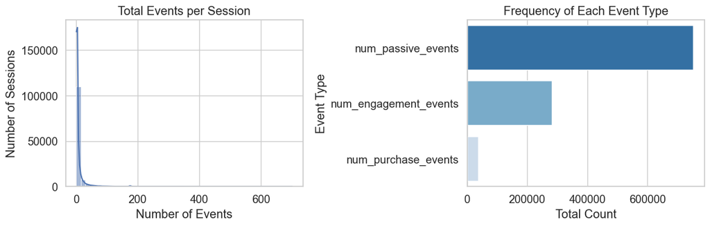

```python
fig, axes = plt.subplots(1, 2, figsize=(12, 4))

# Total events per session
sns.histplot(df_session['num_events_total'], bins=50, kde=True, ax=axes[0])
axes[0].set(title='Total Events per Session', xlabel='Number of Events', ylabel='Number of Sessions')

# Frequency of each event type
event_cols = [col for col in df_session.columns if col.startswith('num_') and col.endswith('_events')]
event_type_totals = df_session[event_cols].sum().sort_values(ascending=False)
sns.barplot(x=event_type_totals.values, y=event_type_totals.index, palette='Blues_r', ax=axes[1])
axes[1].set(title='Frequency of Each Event Type', xlabel='Total Count', ylabel='Event Type')

plt.tight_layout()
plt.show()
```

Most sessions had fewer than 20 events, but a small number showed much higher activity, which could point to deeper engagement. Passive events made up the bulk of user actions, while engagement and purchase events were far less common. This is typical for an e-commerce site with low overall conversion.

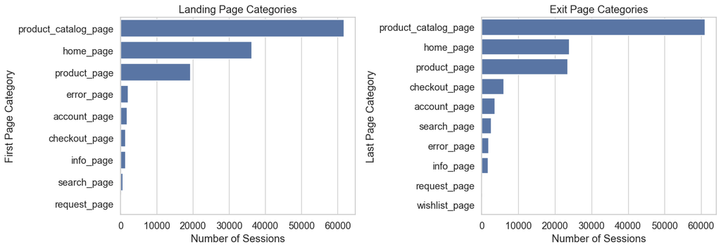

```python
fig, axes = plt.subplots(1, 2, figsize=(14, 5))

# Landing pages
sns.countplot(y='first_page_category', data=df_session,
              order=df_session['first_page_category'].value_counts().index,ax=axes[0])
axes[0].set(title='Landing Page Categories', xlabel='Number of Sessions',ylabel='First Page Category')

# Exit pages
sns.countplot(y='last_page_category',data=df_session,
              order=df_session['last_page_category'].value_counts().index, ax=axes[1])
axes[1].set(title='Exit Page Categories', xlabel='Number of Sessions', ylabel='Last Page Category')

plt.tight_layout()
plt.show()
```

Landing and exit page distributions revealed that most sessions started and ended on product catalog, home, or product pages. Checkout pages were common exit points for converting sessions.

#### B. Engagement Level Analysis

Sessions were classified into three engagement levels:

- Purchaser: At least one purchase event
- Engaged: Engagement events but no purchases
- Passive: Neither engagement nor purchase events

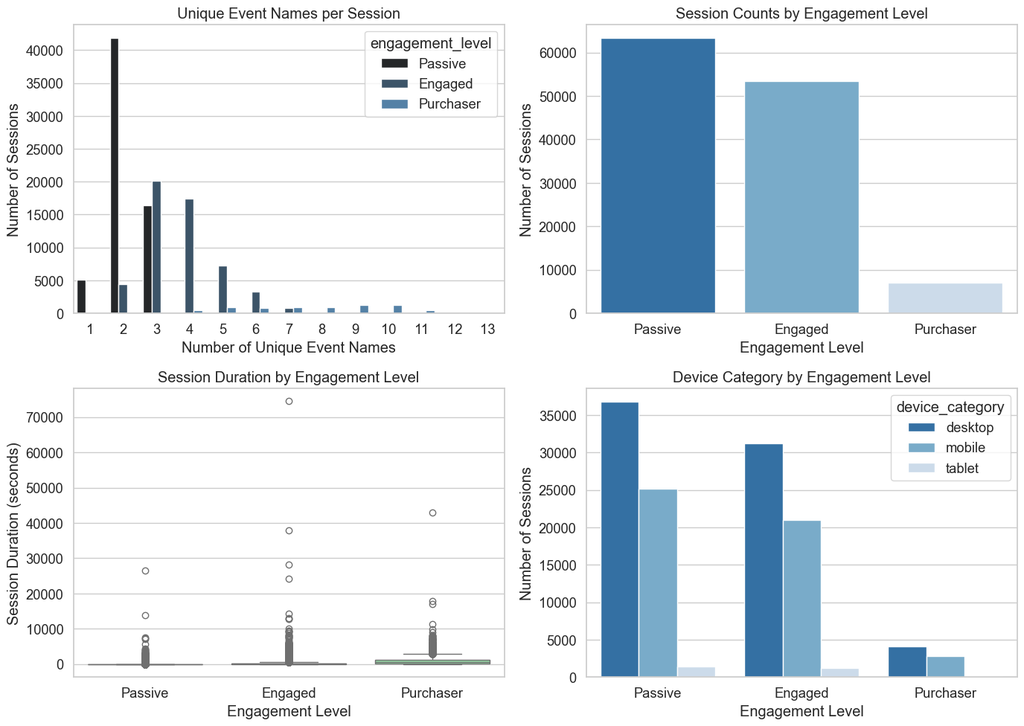

```python
# Assign engagement level
df_session['engagement_level'] = df_session.apply(
    lambda row: 'Purchaser' if row.get('num_purchase_events', 0) > 0
    else 'Engaged' if row.get('num_engagement_events', 0) > 0
    else 'Passive', axis=1
)

fig, axes = plt.subplots(2, 2, figsize=(14, 10))

sns.countplot(x='num_event_names', hue='engagement_level', data=df_session,
              color='steelblue', ax=axes[0, 0])
axes[0, 0].set(title='Unique Event Names per Session', xlabel='Number of Unique Event Names', ylabel='Number of Sessions')

sns.countplot(x='engagement_level', data=df_session,
              order=['Passive', 'Engaged', 'Purchaser'], palette='Blues_r', ax=axes[0, 1])
axes[0, 1].set(title='Session Counts by Engagement Level', xlabel='Engagement Level', ylabel='Number of Sessions')

sns.boxplot(x='engagement_level', y='session_duration', data=df_session,
            order=['Passive', 'Engaged', 'Purchaser'], palette='pastel', ax=axes[1, 0])
axes[1, 0].set(title='Session Duration by Engagement Level', xlabel='Engagement Level', ylabel='Session Duration (seconds)')

sns.countplot(x='engagement_level', hue='device_category', data=df_session,
              order=['Passive', 'Engaged', 'Purchaser'], palette='Blues_r', ax=axes[1, 1])
axes[1, 1].set(title='Device Category by Engagement Level', xlabel='Engagement Level', ylabel='Number of Sessions')

plt.tight_layout()
plt.show()
```

Most sessions were passive, with fewer users engaging or making purchases. Purchaser sessions stood out not only for being longer but also for involving a wider variety of events, while passive sessions tended to include only a few. Engaged sessions fell somewhere in between. Device type appeared to have minimal impact on engagement level distribution.

#### C. Temporal Patterns

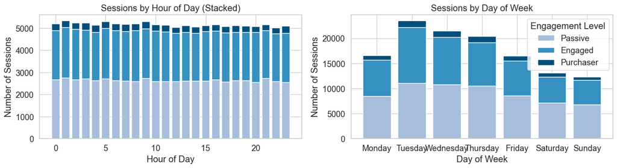

```python
fig, axes = plt.subplots(1, 2, figsize=(14, 4))

order_eng = ['Passive', 'Engaged', 'Purchaser']
colors = ['#a6bddb', '#3690c0', '#034e7b']

# Sessions by Hour of Day
hour_counts = df_session.groupby(['session_hour', 'engagement_level']) \
    .size().unstack(fill_value=0).sort_index()[order_eng]

bottom = np.zeros(len(hour_counts))
for i, level in enumerate(order_eng):
    axes[0].bar(hour_counts.index, hour_counts[level], bottom=bottom, color=colors[i], label=level)
    bottom += hour_counts[level].values

axes[0].set(title='Sessions by Hour of Day (Stacked)', xlabel='Hour of Day', ylabel='Number of Sessions')

# Sessions by Day of Week
order_day = ['Monday', 'Tuesday', 'Wednesday', 'Thursday', 'Friday', 'Saturday', 'Sunday']
day_counts = df_session.groupby(['session_dayofweek', 'engagement_level']) \
    .size().unstack(fill_value=0).reindex(order_day)[order_eng]

bottom = np.zeros(len(day_counts))
for i, level in enumerate(order_eng):
    axes[1].bar(day_counts.index, day_counts[level], bottom=bottom, color=colors[i], label=level)
    bottom += day_counts[level].values

axes[1].set(title='Sessions by Day of Week', xlabel='Day of Week', ylabel='Number of Sessions')
axes[1].legend(title='Engagement Level')

plt.tight_layout()
plt.show()
```

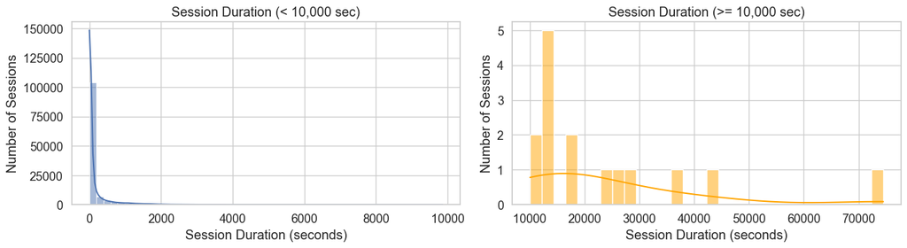

```python
short_sessions = df_session[df_session['session_duration'] < 10000]['session_duration']
long_sessions = df_session[df_session['session_duration'] >= 10000]['session_duration']

fig, axes = plt.subplots(1, 2, figsize=(14, 4))

# Short sessions
sns.histplot(short_sessions, bins=50, kde=True, ax=axes[0])
axes[0].set(title='Session Duration (< 10,000 sec)', xlabel='Session Duration (seconds)', ylabel='Number of Sessions')
axes[0].grid(True)

# Long sessions
sns.histplot(long_sessions, bins=30, kde=True, ax=axes[1], color='orange')
axes[1].set(title='Session Duration (>= 10,000 sec)', xlabel='Session Duration (seconds)', ylabel='Number of Sessions')
axes[1].grid(True)

plt.tight_layout()
plt.show()
```

Session durations were heavily right-skewed. Most lasted under 500 seconds, but a handful ran much longer, which could reflect either deep engagement or outliers. Given this skew, a feature transformation was considered to improve scale consistency for modeling.

Note on Geographic Features: The geo_continent variable was retained for context but excluded from modeling due to limited variability and minimal impact on clustering results. See Appendix A for distribution details.

### 3.3 User-Level Aggregation

To capture more consistent behavioral patterns and reduce session-level variability, features were aggregated at the user level. For each user, session metrics were summarized using the mean, and engagement signals were totaled across all sessions.

In addition to numeric aggregation, each user was assigned an engagement level label based on their cumulative activity, following the same definitions introduced in the previous section. This label was used later for interpreting cluster patterns but not included as an input in the clustering model.

The resulting dataset provided a consolidated view of user behavior across sessions and served as the foundation for clustering and modeling.

```python
def mode(series):
    return series.mode().iloc[0] if not series.mode().empty else np.nan

df_user = df_session.groupby('user_pseudo_id').agg({
    # Averages of session-level metrics
    'session_duration': 'mean',
    'avg_time_between_events': 'mean',
    'num_events_total': 'mean',
    'num_event_names': 'mean',

    # Sum of engagement event types
    'num_engagement_events': 'sum',
    'num_passive_events': 'sum',
    'num_purchase_events': 'sum',

    # Sum of page category views
    'num_account_page_pages': 'sum',
    'num_checkout_page_pages': 'sum',
    'num_error_page_pages': 'sum',
    'num_home_page_pages': 'sum',
    'num_info_page_pages': 'sum',
    'num_product_catalog_page_pages': 'sum',
    'num_product_page_pages': 'sum',
    'num_request_page_pages': 'sum',
    'num_search_page_pages': 'sum',
    'num_wishlist_page_pages': 'sum',

    # Most common categorical attributes
    'first_page_category': mode,
    'last_page_category': mode
}).reset_index()

def classify_user_engagement(row):
    if row['num_purchase_events'] > 0:
        return 'Purchaser'
    elif row['num_engagement_events'] > 0:
        return 'Engaged'
    else:
        return 'Passive'

df_user['engagement_level'] = df_user.apply(classify_user_engagement, axis=1)

df_user.head()
```

|  | user_pseudo_id | session_duration | avg_time_between_events | num_events_total | num_event_names | num_engagement_events | num_passive_events | num_purchase_events | num_account_page_pages | num_checkout_page_pages | ... | num_home_page_pages | num_info_page_pages | num_product_catalog_page_pages | num_product_page_pages | num_request_page_pages | num_search_page_pages | num_wishlist_page_pages | first_page_category | last_page_category | engagement_level |
| --- | --- | --- | --- | --- | --- | --- | --- | --- | --- | --- | --- | --- | --- | --- | --- | --- | --- | --- | --- | --- | --- |
| 0 | 10001363.4360935308 | 0.00 | 0.000000 | 2.00 | 2.0 | 0 | 2 | 0 | 0 | 0 | ... | 2 | 0 | 0 | 0 | 0 | 0 | 0 | home_page | home_page | Passive |
| 1 | 10003031.4607645453 | 0.00 | 0.000000 | 2.00 | 2.0 | 0 | 2 | 0 | 0 | 0 | ... | 0 | 0 | 2 | 0 | 0 | 0 | 0 | product_catalog_page | product_catalog_page | Passive |
| 2 | 1000441.6293401995 | 62.00 | 7.750000 | 9.00 | 3.0 | 4 | 5 | 0 | 0 | 0 | ... | 9 | 0 | 0 | 0 | 0 | 0 | 0 | home_page | home_page | Engaged |
| 3 | 10005335.8064658740 | 145.25 | 14.725379 | 7.25 | 3.5 | 8 | 21 | 0 | 0 | 0 | ... | 2 | 0 | 10 | 8 | 0 | 9 | 0 | product_catalog_page | product_catalog_page | Engaged |
| 4 | 10006188.0272495437 | 0.00 | 0.000000 | 2.00 | 2.0 | 0 | 2 | 0 | 0 | 0 | ... | 0 | 0 | 0 | 2 | 0 | 0 | 0 | product_page | product_page | Passive |

5 rows × 21 columns

The final user-level dataset captures average session behavior and engagement across sessions. Landing and exit pages were kept for interpretation but excluded from modeling. Users were labeled as Passive, Engaged, or Purchaser for evaluation only.

| Column | Description | Usage |
| --- | --- | --- |
| user_pseudo_id | User ID | Excluded (identifier) |
| session_duration | Average session duration across user's sessions | Modeling (numeric) |
| avg_time_between_events | Average seconds between consecutive events across sessions | Modeling (numeric) |
| num_events_total | Average number of events per session | Modeling (numeric) |
| num_event_names | Average number of unique event names per session (engagement diversity) | Modeling (numeric) |
| num_passive_events, num_engagement_events, num_purchase_events | Total counts per event type across all sessions | Modeling (numeric) |
| num_account_page_pages, num_checkout_page_pages, etc. | Total counts of page views per category across all sessions | Modeling (numeric) |
| first_page_category | Most common landing page category | For cluster interpretation only |
| last_page_category | Most common exit page category | For cluster interpretation only |
| engagement_level | User engagement level (Passive, Engaged, Purchaser) | Label (for evaluation & visualization) |

### 3.4 Exploration of Aggregated Data

This section examines user-level features before transformation, highlighting skewed distributions, sparsity, and potential issues that could affect modeling.

```python
# Check percentage of zeros in each feature
zero_pct = ((df_user == 0).sum() / len(df_user) * 100).sort_values(ascending=False)
print(zero_pct)
```

```
num_wishlist_page_pages           99.768866
num_request_page_pages            99.622482
num_error_page_pages              97.685774
num_info_page_pages               97.446936
num_search_page_pages             94.697407
num_purchase_events               93.802727
num_checkout_page_pages           91.790901
num_account_page_pages            91.757194
num_product_page_pages            69.034824
num_home_page_pages               61.297623
num_engagement_events             52.482761
num_product_catalog_page_pages    34.500559
session_duration                  31.922455
avg_time_between_events           31.922455
num_passive_events                 0.026003
first_page_category                0.000000
last_page_category                 0.000000
user_pseudo_id                     0.000000
num_event_names                    0.000000
num_events_total                   0.000000
engagement_level                   0.000000
dtype: float64
```

Histograms of these features are shown below to highlight their original distributions and inform the need for transformation in the next step.

```python
clustering_features = ['session_duration','avg_time_between_events','num_passive_events',
                    'num_engagement_events','num_purchase_events','num_product_catalog_page_pages',
                    'num_event_names','num_events_total']

X_features = df_user[clustering_features].copy()
```

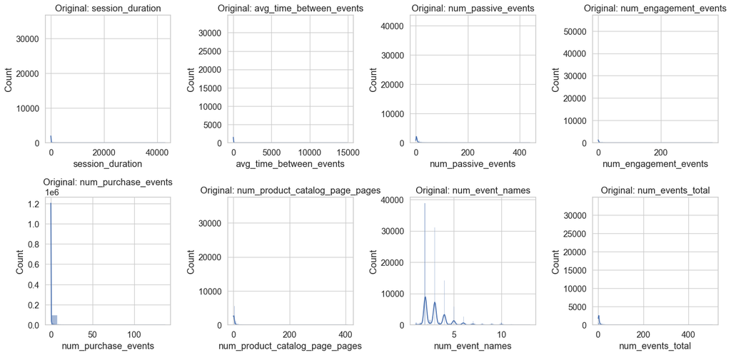

```python
fig, axs = plt.subplots(2, 4, figsize=(16, 8))

for i, col in enumerate(clustering_features):
    sns.histplot(X_features[col], kde=True, ax=axs.flat[i])
    axs.flat[i].set(title=f'Original: {col}')

plt.tight_layout()
plt.show()
```

Most of the features were heavily right-skewed, with values packed near zero and a few extreme outliers. This was especially true for event-related counts like purchases, engagements, and product catalog views. Features like session duration and time between events also had long tails. Others, like the number of unique events or sessions, showed more stepped or discrete patterns. Overall, the distributions suggested that transformation would be helpful before clustering, both to reduce skew and to make the features more comparable.

### 3.5 Variable Transformation

```python
def prepare_clustering_data(df_user, clustering_features, metadata_features):
    """
    Transforms selected features using Yeo-Johnson and returns:
    - Transformed feature matrix (X_transformed)
    - Result DataFrame with metadata and transformed features (df_result)
    """
    X_raw = df_user[clustering_features].copy()
    X_transformed = power_transform(X_raw, method='yeo-johnson')

    df_transformed = pd.DataFrame(X_transformed, columns=clustering_features, index=df_user.index)
    df_result = pd.concat([df_user[metadata_features].copy(), df_transformed], axis=1)

    return X_transformed, df_result
```

```python
metadata_features = ['user_pseudo_id', 'engagement_level','first_page_category', 'last_page_category']

X_transformed, df_result = prepare_clustering_data(df_user, clustering_features, metadata_features)
```

### 3.6 Transformation Diagnostics

The effect of the Yeo-Johnson transformation was evaluated using histograms, CDFs, and Q-Q plots. Most features became more balanced and comparable in scale, making them better suited for clustering. A few showed little change, which was expected given their distribution.

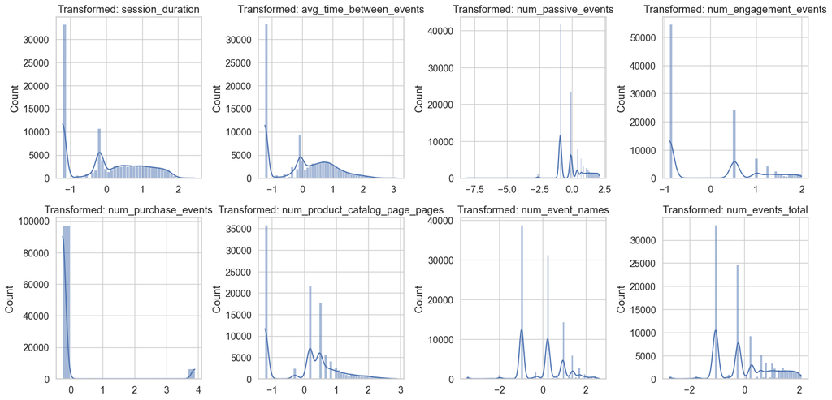

```python
fig, axs = plt.subplots(2, 4, figsize=(16, 8))
for i, col in enumerate(clustering_features):
    ax = axs.flat[i]
    sns.histplot(X_transformed[:, i], kde=True, ax=ax)
    ax.set_title(f'Transformed: {col}')
plt.tight_layout()
plt.show()
```

The figure above shows the distributions of all selected features after applying the Yeo-Johnson transformation. While some features still showed discrete or clustered values (i.e. `num_purchase_events`, `num_event_names`), most became more symmetric and better scaled. To take a closer look, a few representative features were examined using CDF and Q-Q plots to evaluate how well the transformation improved normality and spread.

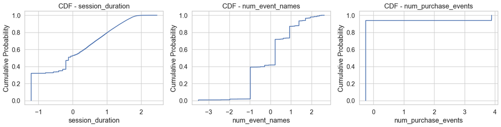

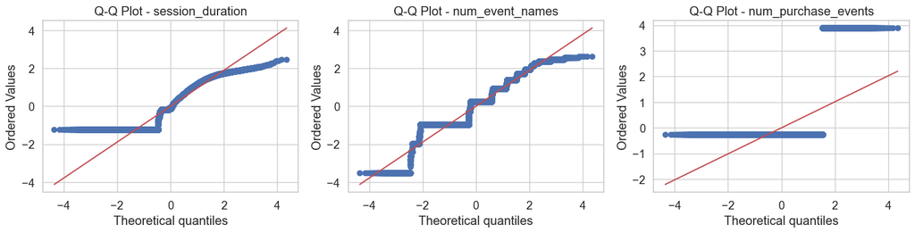

```python
features_to_plot = ['session_duration', 'num_event_names', 'num_purchase_events']

# CDF plots
fig, axes = plt.subplots(1, 3, figsize=(15, 4))
for i, col in enumerate(features_to_plot):
    ecdf = ECDF(df_result[col])
    axes[i].plot(ecdf.x, ecdf.y)
    axes[i].set(title=f'CDF - {col}',xlabel=col,ylabel='Cumulative Probability')
plt.tight_layout()
plt.show()

# Q-Q plots
fig, axes = plt.subplots(1, 3, figsize=(15, 4))
for i, col in enumerate(features_to_plot):
    stats.probplot(df_result[col], dist="norm", plot=axes[i])
    axes[i].set_title(f'Q-Q Plot - {col}')
plt.tight_layout()
plt.show()
```

Looking at the CDF and Q-Q plots for selected features:

- `session_duration` showed a smooth cumulative spread, and its Q-Q plot indicated better alignment with a normal distribution, especially through the midrange.
- `num_event_names` retained a step-like shape due to its discrete values, but the Q-Q plot still showed improved alignment along the diagonal.
- `num_purchase_events`, while still sparse, showed value compression in the CDF. The Q-Q plot reflected the challenge of normalizing such skewed data, but the feature was kept for its strong behavioral relevance and potential to help identify high-value users.

Overall, the transformation helped reduce skew and brought most features closer to a scale more suitable for clustering.

### 3.7 Dimensionality Reduction

To explore the structure of the data before clustering, UMAP was applied to the transformed features and reduced them to 15 dimensions. This helped retain more of the underlying relationships between users while simplifying the input space.

Two distance metrics were tested:

- Euclidean (default): works well when features are scaled and balanced
- Cosine: captures directional similarity in behavior, which can be useful for comparing usage patterns

```python
def umap_embedding(X, n_components=15, metric='euclidean', random_state=4365):
    reducer = umap.UMAP(n_components=n_components, metric=metric, random_state=random_state)
    return reducer.fit_transform(X)

X_umap_euclidean = umap_embedding(X_transformed)
X_umap_cosine = umap_embedding(X_transformed, metric='cosine')
```

For visualization, 2D projections were also created using both metrics to see if any natural groupings emerged.

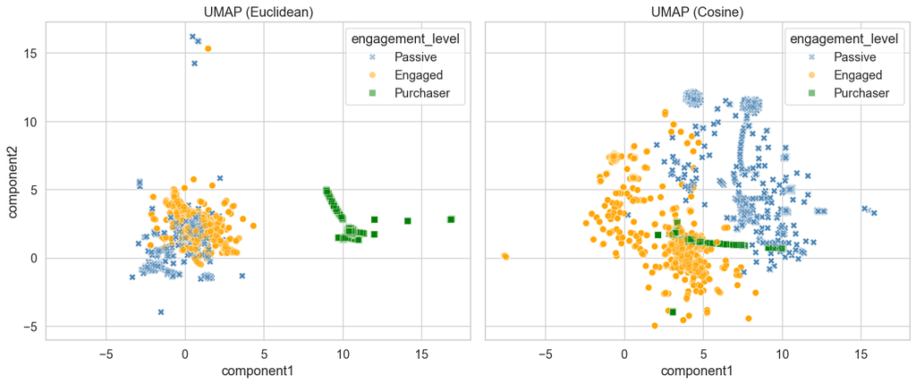

```python
def umap_plot_data(embedding, labels, dim_labels=('component1', 'component2')):
    """Function to format UMAP embedding and attach engagement labels"""
    df_plot = pd.DataFrame(embedding[:, :2], columns=dim_labels)
    df_plot['engagement_level'] = labels.values
    return df_plot

# Prepare UMAP projection dataframes for both Euclidean and Cosine distance metrics
df_umap_plot_ed = umap_plot_data(X_umap_euclidean, df_user['engagement_level'])
df_umap_plot_cs = umap_plot_data(X_umap_cosine, df_user['engagement_level'])

fig, axes = plt.subplots(1, 2, figsize=(14, 6), sharex=True, sharey=True)

for ax, df_plot, title in zip(
    axes,
    [df_umap_plot_ed, df_umap_plot_cs],
    ['UMAP (Euclidean)', 'UMAP (Cosine)']
):
    sns.scatterplot(data=df_plot,x='component1', y='component2',hue='engagement_level',
        style='engagement_level',markers=['X', 'o', 's'],
        palette={'Passive': 'steelblue', 'Engaged': 'orange', 'Purchaser': 'green'},
        alpha=0.5,s=50,ax=ax)
    ax.set_title(title)

plt.tight_layout()
plt.show()
```

In the **Euclidean** projection, `Purchasers` are fairly well separated from the other two groups, while `Passive` and `Engaged` users have more overlap. In the **cosine** projection, the overall distance between groups appears greater, with less overlap between `Passive` and `Engaged`. However, `Purchasers` are spread out in more of a linear band across the two, which might reflect the fact that they tend to perform both passive and engaged behaviors before converting.

### 3.8 Key Findings Informing Modeling

The exploratory analysis and dimensionality reduction surfaced several patterns that shaped the modeling approach. Purchasers and engaged users typically had longer sessions, interacted more frequently, and showed greater behavioral diversity. While the majority of users were passive, higher-value users stood out with stronger engagement signals—both in the raw behavioral metrics and in the UMAP projections.

These findings suggest that meaningful behavioral segmentation is possible, and helped guide decisions around feature selection and clustering methods in the next stage.

## 4. Modeling Approach

Building on patterns observed during exploration, the next phase focused on clustering users based on their aggregated behavioral features. The goal was to uncover meaningful segments that could support personalized marketing strategies and improve the user experience. Several clustering algorithms were applied to explore different grouping structures and check for consistency across methods.

### 4.1 K-Means Clustering

K-Means was chosen as a starting point due to its simplicity and efficiency in handling well-scaled, numeric data. Since the features were transformed to reduce skew and bring them to comparable scales, the assumptions of K-Means were reasonably well met. To evaluate different values of k, WCSS, BCSS, silhouette score, and the Calinski-Harabasz index were computed and plotted. These helped assess the compactness and separation of clusters and guided the selection of a reasonable k for modeling.

```python
def cluster_search_kmeans(df, nclusts=(2,21), n_init=10):
    ## If there are cluster assignments in the data frame remove them.
    if 'kmeans_cluster' in df.columns: df.drop(columns='kmeans_cluster', inplace=True)
    WCSS=[]
    BCSS=[]
    silhouette=[]
    CH_index = []
    ## Compute total sum of squares
    x_bar = np.mean(df, axis=0)
    TSS = np.sum(np.sum(np.square(df - x_bar)))
    for n in range(nclusts[0],nclusts[1]+1):
        temp_model = KMeans(n_clusters=n, n_init=n_init).fit(df)
        WCSS.append(temp_model.inertia_)
        BCSS.append(TSS - temp_model.inertia_)
        assignments = temp_model.predict(df)
        silhouette.append(silhouette_score(df, assignments))
        CH_index.append(calinski_harabasz_score(df, assignments))
    _, ax = plt.subplots(2,2, figsize=(8,8))
    ax = ax.flatten()
    ax[0].plot(range(nclusts[0],nclusts[1]+1),WCSS)
    ax[0].set_xlabel('Number of clusters')
    ax[0].set_ylabel('WCSS')
    ax[1].plot(range(nclusts[0],nclusts[1]+1),BCSS)
    ax[1].set_xlabel('Number of clusters')
    ax[1].set_ylabel('BCSS')
    ax[2].plot(range(nclusts[0],nclusts[1]+1),silhouette)
    ax[2].set_xlabel('Number of clusters')
    ax[2].set_ylabel('Silhouette Score')
    ax[3].plot(range(nclusts[0],nclusts[1]+1),CH_index)
    ax[3].set_xlabel('Number of clusters')
    ax[3].set_ylabel('Calinski Harabasz Score')
```

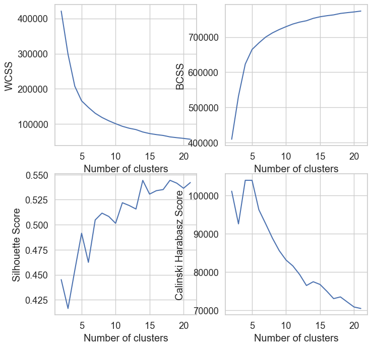

```python
X_clustering = pd.DataFrame(X_transformed, columns=clustering_features)
nr.seed(9966)
cluster_search_kmeans(X_clustering, nclusts=(2,21))
```

**The most balanced choice for k appears to be 5.** The WCSS curve shows a clear elbow at this point, while the BCSS rises quickly up to around k = 5 before leveling off. The silhouette score also increases more sharply near k = 5, and although the Calinski-Harabasz index peaks slightly earlier, it remains relatively high at k = 5 before starting to decline. Taken together, these trends suggest that five clusters offer a good trade-off between compactness, separation, and interpretability.

```python
# Fit K-means clustering with k=5
nr.seed(9966)
kmeans_model = KMeans(n_clusters=5, random_state=42)
kmeans_labels = kmeans_model.fit_predict(X_clustering)
df_result['kmeans_cluster'] = kmeans_labels

score_kmeans = silhouette_score(X_clustering, df_result['kmeans_cluster'])
print(f'Silhouette Score (K-Means): {score_kmeans:.4f}')
```

```
Silhouette Score (K-Means): 0.4915
```

```python
pd.crosstab(df_result['kmeans_cluster'], df_result['engagement_level'])
```

| engagement_level kmeans_cluster | Engaged | Passive | Purchaser |
| --- | --- | --- | --- |
| 0 | 22114 | 378 | 0 |
| 1 | 295 | 33437 | 0 |
| 2 | 4030 | 17874 | 0 |
| 3 | 0 | 0 | 6429 |
| 4 | 16474 | 2799 | 6 |

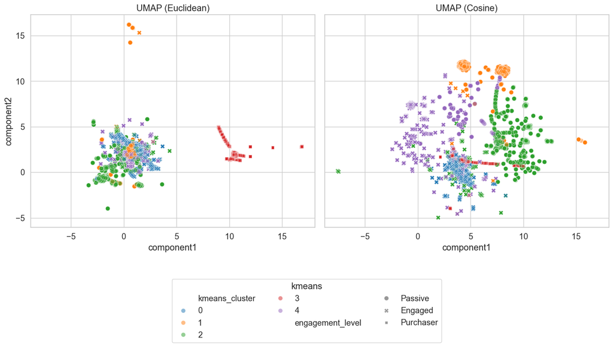

```python
def plot_umap(ax, df, hue_col, style_col=None, title=None, palette='tab10'):
    """Helper function to plot UMAP embeddings with hue and style options"""
    sns.scatterplot(x='component1', y='component2', data=df,
                    hue=hue_col, style=style_col, palette=palette,
                    alpha=0.5, s=50,ax=ax)
    ax.set_title(title or '')
    ax.legend_.remove() # Remove legend from individual plots (will add one shared later)

# Create copies of UMAP projection DataFrames and add cluster and engagement labels
df_plot_ed = df_umap_plot_ed.copy()
df_plot_ed['kmeans_cluster'] = df_result['kmeans_cluster'].values
df_plot_ed['engagement_level'] = df_result['engagement_level'].values

df_plot_cs = df_umap_plot_cs.copy()
df_plot_cs['kmeans_cluster'] = df_result['kmeans_cluster'].values
df_plot_cs['engagement_level'] = df_result['engagement_level'].values

fig, axes = plt.subplots(1, 2, figsize=(14, 6), sharex=True, sharey=True)
plot_umap(axes[0], df_plot_ed, hue_col='kmeans_cluster', style_col='engagement_level', title='UMAP (Euclidean)')
plot_umap(axes[1], df_plot_cs, hue_col='kmeans_cluster', style_col='engagement_level', title='UMAP (Cosine)')
handles, labels = axes[1].get_legend_handles_labels()
fig.legend(handles, labels, title='kmeans', loc='upper center', bbox_to_anchor=(0.5, -0.05), ncol=3)

plt.tight_layout()
plt.show()
```

### 4.2 DBSCAN

Unlike K-Means, DBSCAN doesn't require specifying the number of clusters up front and can identify clusters of varying shapes and densities. It’s also useful for filtering out noise or outlier points that don’t belong to any cluster. Given that user behavior may not fall into clean, spherical groups, DBSCAN offers a more flexible approach to uncovering structure in the data.

To explore this, a small grid of eps and min_samples values was tested across both UMAP projections (Euclidean and Cosine), and clustering quality was evaluated using silhouette scores and noise levels.

```python
def evaluate_dbscan_model(X, umap_label, eps, min_samples, leaf_size=60):
    """Fits a DBSCAN model on the input data and evaluates clustering quality."""
    # Fit DBSCAN model
    model = DBSCAN(eps=eps, min_samples=min_samples, leaf_size=leaf_size)
    labels = model.fit_predict(X)

    # Count clusters and noise points
    n_clusters = len(set(labels)) - (1 if -1 in labels else 0)
    n_noise = list(labels).count(-1)

    # Filter out overly fragmented or empty clusterings
    if n_clusters > 50 or n_clusters == 0 or n_noise == len(labels):
        score = None
    else:
        score = silhouette_score(X, labels, sample_size=10000, random_state=42)

    # Return evaluation metrics
    return {
        'umap_space': umap_label,
        'eps': eps,
        'min_samples': min_samples,
        'leaf_size': leaf_size,
        'clusters': n_clusters,
        'noise': n_noise,
        'silhouette': score
    }
```

```python
eps_range = [0.8, 1.0]
min_samples_range = [200, 250, 300]
leaf_size = 60

# Create list of delayed evaluation jobs for UMAP-Euclidean space
jobs = [
    delayed(evaluate_dbscan_model)(X_umap_euclidean, 'euclidean', eps, min_samples, leaf_size)
    for eps in eps_range for min_samples in min_samples_range
] + [
    # Append evaluation jobs for UMAP-Cosine space
    delayed(evaluate_dbscan_model)(X_umap_cosine, 'cosine', eps, min_samples, leaf_size)
    for eps in eps_range for min_samples in min_samples_range
]

# Run all DBSCAN jobs in parallel using 3 workers
results = Parallel(n_jobs=3, backend='loky')(tqdm(jobs, desc="Running DBSCAN grid search"))

df_dbscan_results = pd.DataFrame(results)
```

```python
# Top 10 DBSCAN configurations by silhouette score
df_dbscan_results.sort_values(by='silhouette', ascending=False).head(10)
```

|  | umap_space | eps | min_samples | leaf_size | clusters | noise | silhouette |
| --- | --- | --- | --- | --- | --- | --- | --- |
| 3 | euclidean | 1.0 | 200 | 60 | 39 | 23998 | 0.490039 |
| 0 | euclidean | 0.8 | 200 | 60 | 39 | 24683 | 0.480692 |
| 4 | euclidean | 1.0 | 250 | 60 | 32 | 25705 | 0.469183 |
| 9 | cosine | 1.0 | 200 | 60 | 42 | 23057 | 0.466129 |
| 5 | euclidean | 1.0 | 300 | 60 | 29 | 26651 | 0.461660 |
| 7 | cosine | 0.8 | 250 | 60 | 30 | 27463 | 0.453805 |
| 1 | euclidean | 0.8 | 250 | 60 | 30 | 27107 | 0.450290 |
| 10 | cosine | 1.0 | 250 | 60 | 30 | 25939 | 0.438422 |
| 11 | cosine | 1.0 | 300 | 60 | 28 | 26915 | 0.429925 |
| 6 | cosine | 0.8 | 200 | 60 | 41 | 24623 | 0.427905 |

**Final DBSCAN Model and Cluster Evaluation**

The final DBSCAN model was fit using the best-performing setup (`eps=1.0`, `min_samples=200`).

```python
# Fit DBSCAN model using best-performing setup
dbscan_final = DBSCAN(eps=1.0, min_samples=200, leaf_size=60)
dbscan_labels = dbscan_final.fit_predict(X_umap_euclidean)
df_result['dbscan_cluster'] = dbscan_labels

# Evaluate Model
n_clusters = len(set(dbscan_labels)) - (1 if -1 in dbscan_labels else 0)
n_noise = np.sum(dbscan_labels == -1)
print(f"DBSCAN identified {n_clusters} clusters with {n_noise} noise points.")
score = silhouette_score(X_umap_euclidean, dbscan_labels, sample_size=10000, random_state=42)
print(f'Silhouette Score (DBSCAN): {score:.4f}')
```

```
DBSCAN identified 39 clusters with 23998 noise points.
Silhouette Score (DBSCAN): 0.4900
```

```python
# Get the top 15 largest DBSCAN clusters
top_dbscan_clusters = df_result['dbscan_cluster'].value_counts().nlargest(15).index

pd.crosstab(df_result.loc[df_result['dbscan_cluster'].isin(top_dbscan_clusters), 'dbscan_cluster'],
            df_result['engagement_level'])
```

| engagement_level dbscan_cluster | Engaged | Passive | Purchaser |
| --- | --- | --- | --- |
| -1 | 12136 | 11263 | 599 |
| 0 | 0 | 13792 | 0 |
| 1 | 0 | 17643 | 0 |
| 2 | 2552 | 0 | 0 |
| 3 | 16198 | 0 | 0 |
| 4 | 0 | 0 | 5132 |
| 5 | 0 | 1427 | 0 |
| 6 | 1058 | 0 | 0 |
| 7 | 0 | 2154 | 0 |
| 9 | 4416 | 0 | 0 |
| 11 | 0 | 1634 | 0 |
| 13 | 2083 | 0 | 0 |
| 14 | 0 | 1160 | 0 |
| 17 | 0 | 0 | 704 |
| 19 | 0 | 1303 | 0 |

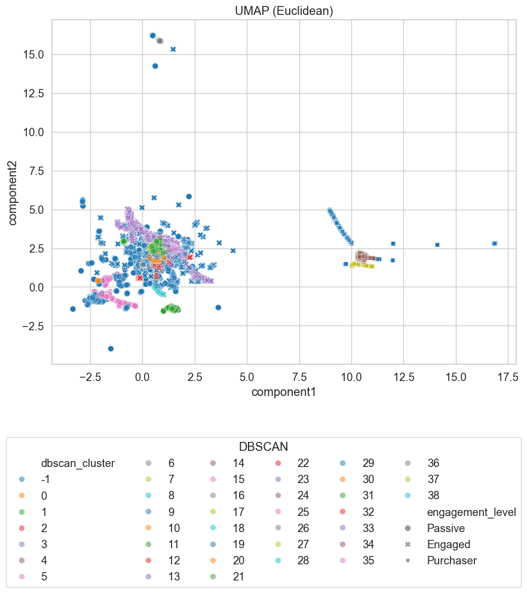

```python
df_plot_ed['dbscan_cluster'] = df_result['dbscan_cluster'].values

fig, ax = plt.subplots(figsize=(9, 7))
plot_umap(ax, df_plot_ed, hue_col='dbscan_cluster', style_col='engagement_level', title='UMAP (Euclidean)')
handles, labels = ax.get_legend_handles_labels()
fig.legend(handles, labels, title='DBSCAN', loc='upper center', bbox_to_anchor=(0.5, -0.05), ncol=6)

plt.tight_layout()
plt.show()
```

DBSCAN provided a more flexible alternative to K-Means by clustering based on density rather than enforcing uniform group sizes. Using `eps=1.0` and `min_samples=200`, the final model identified **39 clusters** with a silhouette score around **0.49** and marked roughly 24,000 users as noise. What stood out was how cleanly DBSCAN separated users by engagement level. Also, instead of lumping users into a few broad groups, DBSCAN surfaced finer-grained segments within each engagement level, revealing behavioral structure that K-Means missed.

### 4.3 OPTICS

OPTICS was also applied to explore alternative clustering structures. To ensure a fair comparison with DBSCAN, the parameters were kept consistent: `min_samples=200`,`max_eps=1.0`,`leaf_size=60`, and `metric='euclidean'`. Like DBSCAN, OPTICS doesn't require a predefined number of clusters and can handle variable density.

```python
# Fit OPTICS model using the same hyperparameters
optics = OPTICS(min_samples=200, max_eps=1.0, leaf_size=60, metric='euclidean')
optics_labels = optics.fit_predict(X_umap_euclidean)
df_result['optics_cluster'] = optics_labels

# Evaluate Model
n_clusters = len(set(optics_labels)) - (1 if -1 in optics_labels else 0)
n_noise = np.sum(optics_labels == -1)
print(f"OPTICS identified {n_clusters} clusters with {n_noise} noise points.")
score = silhouette_score(X_umap_euclidean, optics_labels, sample_size=10000, random_state=42)
print(f'Silhouette Score (OPTICS): {score:.4f}')
```

```
OPTICS identified 41 clusters with 40260 noise points.
Silhouette Score (OPTICS): 0.3538
```

```python
# Get the top 15 largest OPTICS clusters
top_optics_clusters = df_result['optics_cluster'].value_counts().nlargest(15).index

pd.crosstab(df_result.loc[df_result['optics_cluster'].isin(top_optics_clusters), 'optics_cluster'],
            df_result['engagement_level'])
```

| engagement_level optics_cluster | Engaged | Passive | Purchaser |
| --- | --- | --- | --- |
| -1 | 27283 | 12378 | 599 |
| 0 | 0 | 13792 | 0 |
| 1 | 0 | 17643 | 0 |
| 4 | 2339 | 0 | 0 |
| 6 | 0 | 0 | 5132 |
| 8 | 1058 | 0 | 0 |
| 9 | 0 | 2154 | 0 |
| 11 | 4416 | 0 | 0 |
| 13 | 0 | 1634 | 0 |
| 15 | 2083 | 0 | 0 |
| 16 | 0 | 1160 | 0 |
| 19 | 0 | 0 | 704 |
| 21 | 0 | 1303 | 0 |
| 23 | 0 | 589 | 0 |
| 31 | 561 | 0 | 0 |

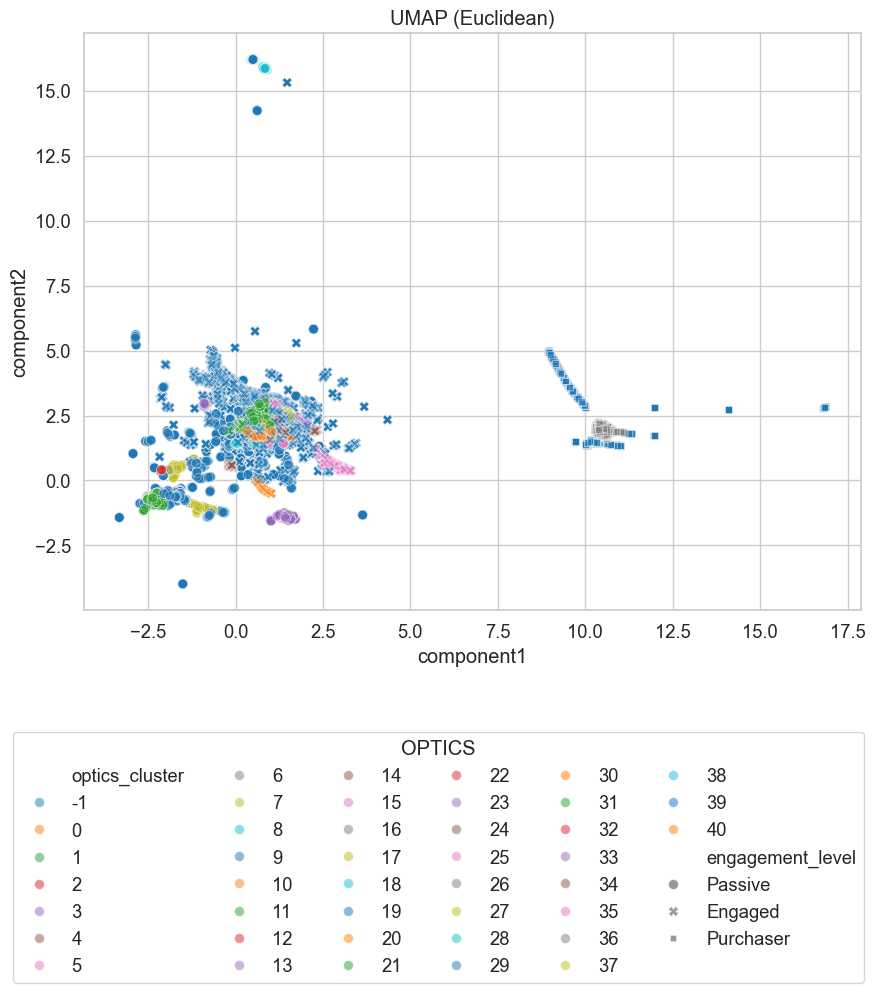

```python
df_plot_ed['optics_cluster'] = df_result['optics_cluster'].values

fig, ax = plt.subplots(figsize=(9, 7))
plot_umap(ax, df_plot_ed, hue_col='optics_cluster', style_col='engagement_level', title='UMAP (Euclidean)')
handles, labels = ax.get_legend_handles_labels()
fig.legend(handles, labels, title='OPTICS', loc='upper center', bbox_to_anchor=(0.5, -0.05), ncol=6)

plt.tight_layout()
plt.show()
```

### 4.4 Comparison and Evaluation of Clustering Methods

Among the three methods, **DBSCAN** was selected as the most effective clustering approach for this dataset. It achieved a silhouette score comparable to KMeans while revealing more granular structure within user behavior. It successfully isolated Purchasers into distinct clusters and showed clear groupings among Passive and Engaged users. Compared to OPTICS, DBSCAN produced fewer noise points and more balanced cluster sizes. Its flexibility in handling different densities and shapes of user behavior made it a better fit for segmentation and interpretation.

| Method | Clusters | Noise Points | Silhouette Score | Notes |
| --- | --- | --- | --- | --- |
| **K-Means** | 5 | 0 | **0.4915** | Clearly separated Purchasers into one group but struggled to distinguish Passive from Engaged users. |
| **DBSCAN** | 39 | 23,998 | **0.4900** | Flexible and revealed more granularity within engagement levels. Clusters were cleanly aligned with labels. |
| **OPTICS** | 41 | 40,260 | **0.3538** | Similar to DBSCAN but with more users flagged as noise. Cluster purity was still strong, especially for Passive and Engaged users. |

### 4.5 Cluster Interpretation and Behavioral Patterns

To better understand behavioral differences across segments, top clusters from each engagement level were examined. Instead of focusing on features that directly define engagement (like `num_purchase_events`), the analysis looked at broader patterns, such as session duration, event diversity, and catalog activity, to compare how users interact with the site. This helped surface meaningful distinctions in browsing depth and engagement style across clusters.

```python
engagement_counts = pd.crosstab(df_result['dbscan_cluster'], df_result['engagement_level'])
engagement_counts = engagement_counts[engagement_counts.index != -1] # remove noise

# Top 3 clusters for each engagement level
top_purchaser_clusters = engagement_counts[engagement_counts['Purchaser'] > 0].sort_values('Purchaser', ascending=False).head(3).index.tolist()
top_engaged_clusters = engagement_counts[engagement_counts['Engaged'] > 0].sort_values('Engaged', ascending=False).head(3).index.tolist()
top_passive_clusters = engagement_counts[engagement_counts['Passive'] > 0].sort_values('Passive', ascending=False).head(3).index.tolist()

top_clusters = top_purchaser_clusters + top_engaged_clusters + top_passive_clusters
summary = df_result[df_result['dbscan_cluster'].isin(top_clusters)].groupby(['dbscan_cluster', 'engagement_level'])[clustering_features].mean().round(2)

summary
```

| dbscan_cluster | engagement_level | session_duration | avg_time_between_events | num_passive_events | num_engagement_events | num_purchase_events | num_product_catalog_page_pages | num_event_names | num_events_total |
| --- | --- | --- | --- | --- | --- | --- | --- | --- | --- |
| 0 | Passive | -1.21 | -1.24 | -0.91 | -0.89 | -0.26 | -1.22 | -0.98 | -1.05 |
| 1 | Passive | -1.21 | -1.24 | -0.91 | -0.89 | -0.26 | 0.19 | -0.98 | -1.05 |
| 2 | Engaged | 0.83 | 0.84 | 0.83 | 1.12 | -0.26 | -1.22 | 0.45 | 0.73 |
| 3 | Engaged | 1.14 | 0.98 | 1.29 | 1.31 | -0.26 | 1.05 | 0.86 | 1.20 |
| 4 | Purchaser | 1.39 | 0.93 | 1.67 | 1.64 | 3.89 | 1.43 | 1.68 | 1.68 |
| 7 | Passive | -0.20 | -0.08 | -0.09 | -0.89 | -0.26 | 0.48 | 0.23 | -0.22 |
| 9 | Engaged | -0.20 | -0.08 | -0.91 | 0.53 | -0.26 | -1.22 | 0.23 | -0.22 |
| 17 | Purchaser | 0.90 | 0.66 | 0.78 | 1.24 | 3.89 | -1.22 | 1.32 | 1.20 |

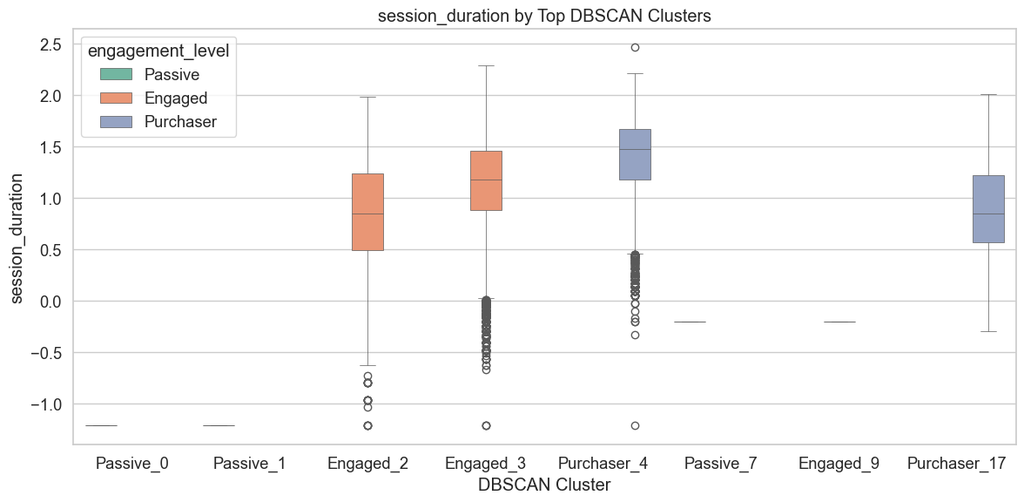

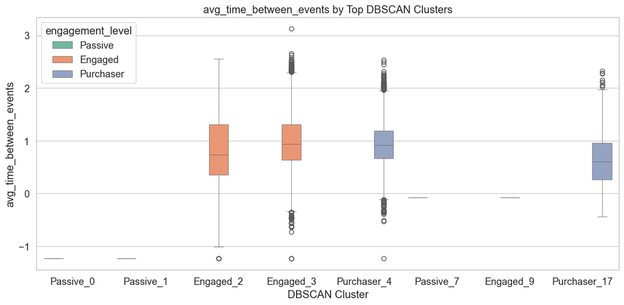

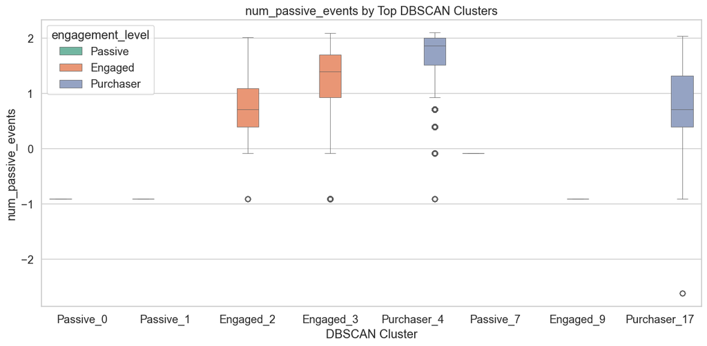

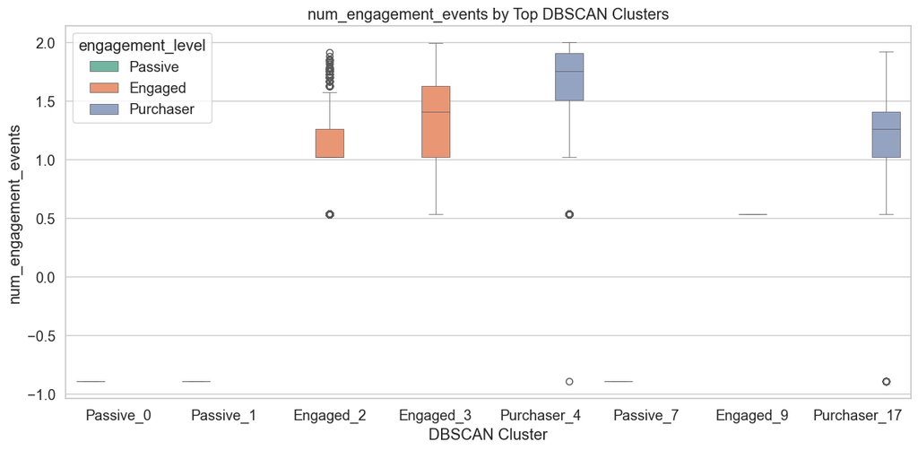

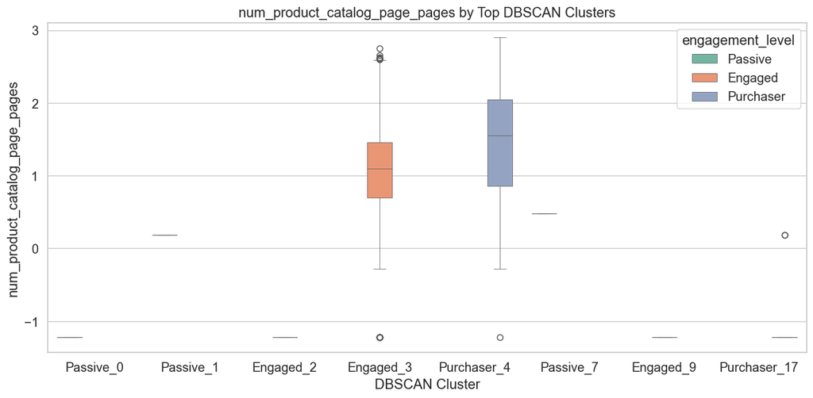

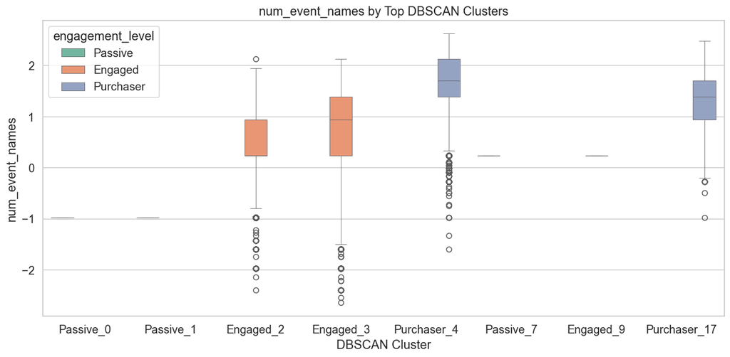

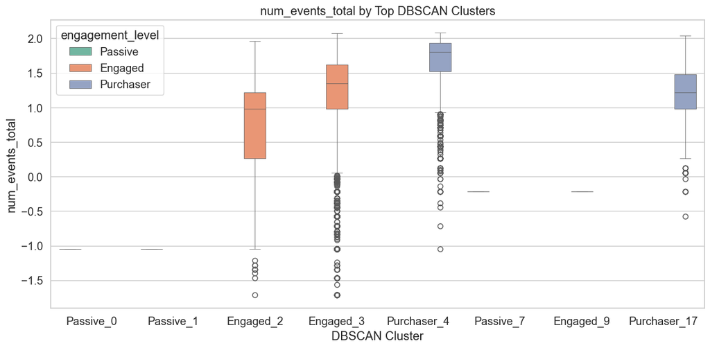

```python
df_result['cluster_label'] = df_result.apply(lambda row: f"{row['engagement_level']}_{row['dbscan_cluster']}"
    if row['dbscan_cluster'] != -1 else 'Noise', axis=1)

top_clusters = [0, 1, 2, 3, 4, 7, 9, 17]
features_to_plot = ['session_duration','avg_time_between_events','num_passive_events','num_engagement_events','num_product_catalog_page_pages','num_event_names','num_events_total']

for feature in features_to_plot:
    fig, ax = plt.subplots(figsize=(12, 6))
    sns.boxplot(
        x='cluster_label', y=feature, hue='engagement_level',
        data=df_result[df_result['dbscan_cluster'].isin(top_clusters)],
        palette='Set2', dodge=True, linewidth=0.5, ax=ax
    )
    ax.set(title=f'{feature} by Top DBSCAN Clusters',xlabel='DBSCAN Cluster',ylabel=feature)
    plt.tight_layout()
    plt.show()
```

#### Clusters Takeaways

The top clusters within each engagement group highlight distinct patterns in user behavior, offering insight into where different users are in their journey and how they might be guided toward deeper engagement or conversion.

**Purchaser Clusters**

- *Cluster 4 (**Deliberate Shoppers**)*: Long sessions, higher time between events, and elevated counts across passive, engagement, and product catalog views. These users also triggered a wide range of events, suggesting exploratory behavior, likely browsing thoroughly before making a purchase.
- *Cluster 17 (**Intentional Buyers**)*: Shorter, more efficient sessions with fewer catalog views but still a high variety of events. These users were likely goal-driven and knew exactly what they wanted.

**Engaged Clusters**

- *Cluster 2 (**Casual Browsers**)*: Moderate session length with steady engagement, limited product catalog views, and balanced activity. These users show interest but don’t explore deeply.
- *Cluster 3 (**High-Intent Browsers**)*: Longer sessions with high engagement and broad interaction across the site. This group appears highly interested but didn’t convert, possibly still evaluating.
- *Cluster 9 (**Drive-By Browsers**)*: Short sessions with light engagement. These users likely came in to check something specific and left quickly—possibly returning users doing quick lookups.

**Passive Clusters**

- *Cluster 0 (**Barely There**)*: Very short sessions with minimal interaction. Likely casual visitors with little intent to explore or convert.
- *Cluster 1 (**Window Shoppers**)*: Similar to Cluster 0 but with more product catalog views—could be early-stage browsers or visitors landing on category pages.
- *Cluster 7 (**Early Explorers**)*: Slightly more event diversity than other passive users. Possibly users who began exploring but dropped off early.

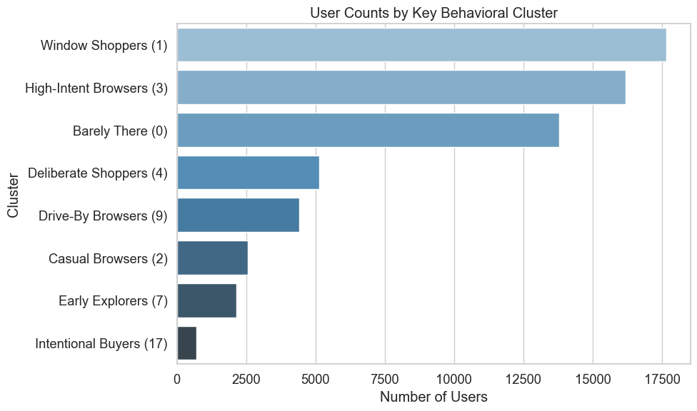

```python
cluster_names = [
    'Barely There (0)',
    'Window Shoppers (1)',
    'Casual Browsers (2)',
    'High-Intent Browsers (3)',
    'Deliberate Shoppers (4)',
    'Early Explorers (7)',
    'Drive-By Browsers (9)',
    'Intentional Buyers (17)'
]

# Count users in each top cluster
topcluster_size = df_result['dbscan_cluster'].value_counts().reindex(top_clusters)
topcluster_size.index = cluster_names
topcluster_size = topcluster_size.sort_values(ascending=False)

fig,ax = plt.subplots(figsize=(10, 6))
sns.barplot(x=topcluster_size.values, y=topcluster_size.index, palette='Blues_d',ax=ax)
ax.set(title='User Counts by Key Behavioral Cluster', xlabel='Number of Users', ylabel='Cluster')
plt.tight_layout()
plt.show()
```

Among the key clusters, "Window Shoppers" and "High-Intent Browsers" made up the largest share of users, followed by "Barely There" visitors. Meanwhile, the number of users who actually converted, "Deliberate Shoppers" and "Intentional Buyers", was much smaller. This contrast points to a clear opportunity: helping more users move from browsing into buying.

Notably, both "Window Shoppers" and "High-Intent Browsers" showed meaningful interaction with product catalog pages, suggesting they were exploring options and could be nudged further down the funnel. On the other hand, groups like "Drive-By Browsers", "Casual Browsers", and "Early Explorers" showed more fragmented or shallow engagement, which may make them harder to convert without a more tailored approach.

### 4.6 Navigating User Journeys Between Browsing and Conversion

To build on the clustering results, this section compares navigation patterns between two key groups:

- High-Intent Browsers (Cluster 3): Showed high engagement but no purchase
- Deliberate Shoppers (Cluster 4): Converted after longer browsing sessions

The goal is to understand how user journeys differ between these groups by analyzing the pages they visit, the paths they follow, and where they tend to drop off. These insights can inform strategies to reduce friction, improve key touchpoints, and better support users in moving toward conversion.

```python
# Filter event-level data for relevant users
selected_users = df_result[df_result['dbscan_cluster'].isin([3, 4])][['user_pseudo_id', 'dbscan_cluster']]
df_journey = df_event.merge(selected_users, on=['user_pseudo_id'], how='inner')
df_journey.head()
```

|  | user_pseudo_id | ga_session_id | event_timestamp | event_name | event_category | cleaned_page_title | page_category | device_category | device_mobile_brand_name | geo_continent | time_diff | dbscan_cluster |
| --- | --- | --- | --- | --- | --- | --- | --- | --- | --- | --- | --- | --- |
| 0 | 10005335.8064658740 | 1.243001e+09 | 2020-12-12 07:38:40 | page_view | passive | Malibu Sunglasses | product_page | desktop | Google | Asia | NaN | 3 |
| 1 | 10005335.8064658740 | 1.243001e+09 | 2020-12-12 07:38:40 | first_visit | passive | Malibu Sunglasses | product_page | desktop | Google | Asia | 0.0 | 3 |
| 2 | 10005335.8064658740 | 1.243001e+09 | 2020-12-12 07:38:45 | view_item | engagement | Malibu Sunglasses | product_page | desktop | Google | Asia | 5.0 | 3 |
| 3 | 10005335.8064658740 | 1.243001e+09 | 2020-12-12 07:39:02 | page_view | passive | Store search results | search_page | desktop | Google | Asia | 17.0 | 3 |
| 4 | 10005335.8064658740 | 1.243001e+09 | 2020-12-12 07:39:02 | view_search_results | engagement | Store search results | search_page | desktop | Google | Asia | 0.0 | 3 |

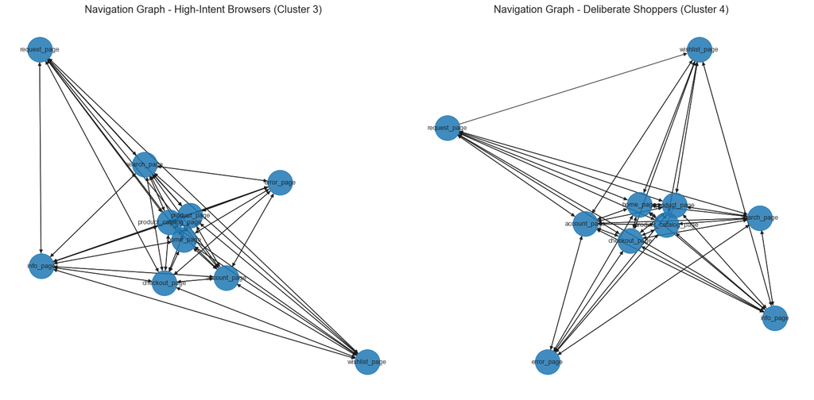

```python
fig, axes = plt.subplots(1, 2, figsize=(16, 8))
cluster_titles = {
    3: "High-Intent Browsers (Cluster 3)",
    4: "Deliberate Shoppers (Cluster 4)"
}
# Loop through each key cluster and create a navigation graph
for ax, cluster_num in zip(axes, [3, 4]):
    # Get only the rows for the current cluster and sort by user and time
    df_cluster = df_journey[df_journey['dbscan_cluster'] == cluster_num].sort_values(['user_pseudo_id', 'event_timestamp'])

    # Get the next page for each user (based on event order)
    df_cluster['next_page'] = df_cluster.groupby('user_pseudo_id')['page_category'].shift(-1)

    # Keep only valid transitions (no missing values, no duplicates like A -> A)
    transitions = df_cluster.dropna(subset=['page_category', 'next_page'])
    transitions = transitions[transitions['page_category'] != transitions['next_page']]

    # Get and sort transition counts
    transition_counts = transitions.groupby(['page_category', 'next_page']).size().reset_index(name='count')
    top_transitions = transition_counts.sort_values('count', ascending=False)

    # Create a directed graph and add edges based on transition counts
    G = nx.DiGraph() # Using DiGraph to show the arrows
    for _, row in top_transitions.iterrows():
        G.add_edge(row['page_category'], row['next_page'], weight=row['count'])

    pos = nx.spring_layout(G, k=0.7, seed=42)
    nx.draw_networkx(G, pos, ax=ax, with_labels=True, node_size=1200, font_size=9, arrows=True, alpha=0.85)
    ax.set_title(f'Navigation Graph - {cluster_titles[cluster_num]}')
    ax.axis('off')

plt.tight_layout()
plt.show()
```

Based on the user journey graphs, a few patterns stand out:

**Common Ground**: Both groups frequently visited core shopping pages like `home_page`, `product_catalog_page`, and `product_page`, reflecting similar interest in browsing and exploring products.

**Deliberate Shoppers (Cluster 4)**: These users moved through the site in a more structured way and showed signs of purposeful behavior.

- Their sessions followed a clear path through key shopping pages and into checkout.
- They also used features like `wishlist_page`, `account_page`, and `info_page`, which likely helped them make a purchase decision.
- Very few ended up on `error_page`, suggesting a smoother overall experience.

**High-Intent Browsers (Cluster 3)**: These users demonstrated strong interest and explored deeply, reaching checkout pages but ultimately not converting.

- They spent time on product and checkout pages, but didn’t convert.
- More sessions hit `error_page` or `request_page`, which may point to friction or gaps in the experience.
- Fewer visits to supporting pages like `wishlist_page` and `info_page` could also signal a lack of reinforcement at key points in their decision process.

## 5. Conclusion and Recommendations

This project explored how users interact with the site by grouping them based on behavioral patterns observed through session and user-level features. Using a mix of clustering techniques, including DBSCAN, K-Means, and OPTICS, the analysis surfaced clear segments ranging from casual visitors to highly engaged users and purchasers.

An important takeaway from this project was the critical role of data preparation when applying density-based clustering methods. Early attempts to run DBSCAN and OPTICS on the MinMax-scaled feature set consistently failed, often crashing the kernel due to the zero-inflated and skewed nature of the data, which led to instability in distance calculations. Closer inspection revealed that many variables contained a large proportion of zeros, creating a feature space where most observations were effectively equidistant, violating the assumptions of distance-based algorithms. This resulted in near-zero eigenvalues in the model matrix, making the data highly unstable for clustering.

Additionally, skewed distributions and potential outliers further distorted the feature space.Applying the Yeo-Johnson transformation helped reduce skewness across many variables, improving spacing between observations and making the data more suitable for clustering. This process reinforced the importance of thorough exploratory data analysis and thoughtful transformation before applying clustering techniques.

Among the methods tested, DBSCAN offered the most meaningful segmentation, revealing more nuanced clusters without needing to predefine the number of groups. It also aligned closely with engagement levels, making it a strong choice for interpreting user behavior and identifying opportunities for action.

To further understand what drives conversion, user journey flows were compared between high-intent browsers and deliberate shoppers. While both groups engaged with key product and catalog pages, deliberate shoppers moved through the funnel more smoothly and made use of supporting tools like wishlists and info pages. In contrast, high-intent browsers were more likely to hit friction points, including error and request pages.

Drawing from these patterns, the following recommendations highlight areas where targeted improvements could enhance user experience and boost conversions:

- **Streamline the shopping path**: Strengthen connections between product and checkout pages. Make helpful tools like wishlists and info pages more visible to support decision-making.
- **Reduce friction for high-intent users**: Investigate common pain points such as error and request pages. These may be causing unnecessary drop-offs, even among users showing strong interest.
- **Tailor follow-ups based on behavior**: Use cluster insights to inform personalized re-engagement strategies. For example, prompt high-intent users with reminders or nudges tailored to their previous browsing behavior.
- **Keep monitoring for shifts**: Re-run clustering periodically to track evolving user behavior. New campaigns, site changes, or seasonality could shift how users navigate and convert.

While this analysis offers a strong starting point, there’s room for deeper exploration. Future work could incorporate additional behavioral signals or alternative modeling approaches to further refine segmentation and support more adaptive, personalized strategies.

## Appendix

### A. Distribution of Engagement Level by Geographic Continent

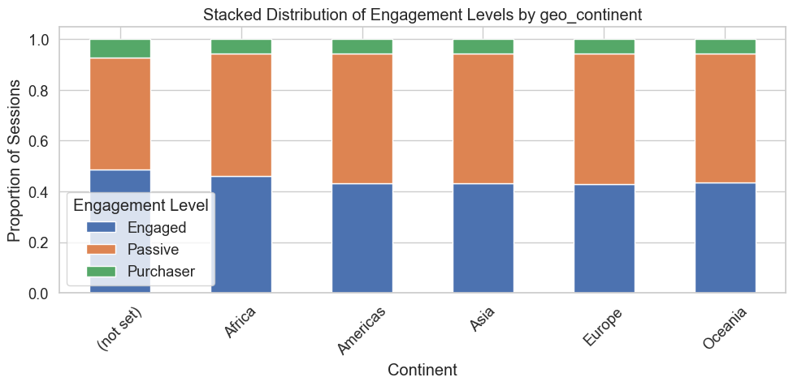